# Exploratory Data Analysis of Attrition by DDSAnalytics Company

#### In order to determine the best model to use, I compare them. By using Mallow’s Cp, adjusted r^2, AIC, and PRESS in conjunction as metrics, I can feel confident in our model selection of best fit.

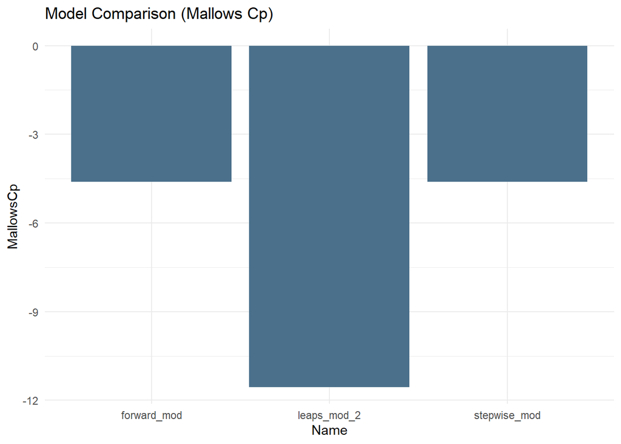

```r
comp <- tribble(
  ~Name, ~MallowsCp, ~ adjr2, ~AIC, ~PRESS,
  "forward_mod", -4.608704, 0.947, 14598.34, 983282198,
  "leaps_mod_2", -11.54697, 0.948, 14592.87, 976097763,
  "stepwise_mod", -4.608704, 0.947, 14598.34, 983282198,
)

comp %>% ggplot(aes(x = Name, y = MallowsCp))+
  geom_bar(stat = 'identity', fill = 'skyblue4') +
  theme_minimal() + ggtitle("Model Comparison (Mallows Cp)")
```

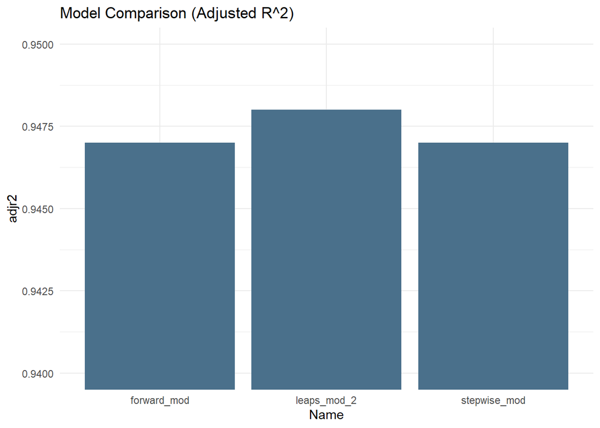

```r
### leaps_mod_2 has lowest Mallows Cp statistic, although it is uncommon to have all models with negative values in this metric

comp %>% ggplot(aes(x = Name, y = adjr2))+
  geom_bar(stat = 'identity', fill = 'skyblue4') + coord_cartesian(ylim = c(0.94, 0.95)) +
  theme_minimal() + ggtitle("Model Comparison (Adjusted R^2)")
```

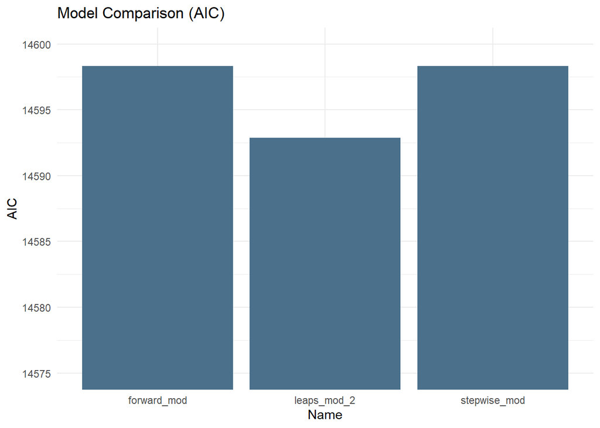

```r
### leaps_mod_2 has highest adjusted r^2


comp %>% ggplot(aes(x = Name, y = AIC))+
  geom_bar(stat = 'identity', fill = 'skyblue4') + coord_cartesian(ylim = c(14575, 14600)) +
  theme_minimal() + ggtitle("Model Comparison (AIC)")
```

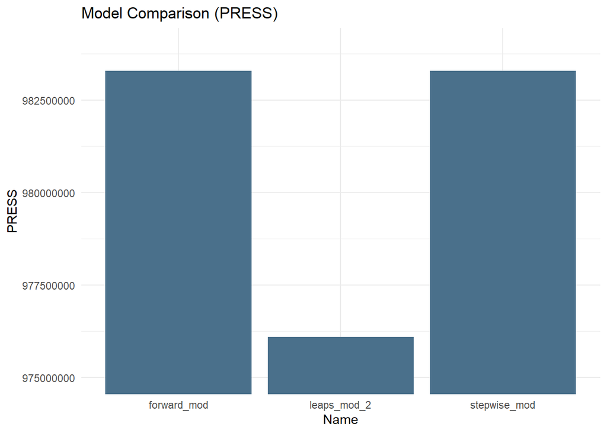

```r
### leaps_mod_2 has lowest AIC


comp %>% ggplot(aes(x = Name, y = PRESS))+
  geom_bar(stat = 'identity', fill = 'skyblue4') + coord_cartesian(ylim = c(975000000, 984000000)) + theme_minimal() + ggtitle("Model Comparison (PRESS)")
```

```r
### leaps_mod_2 has lowest CV PRESS statistic
```

#### By all metrics, leaps_mod_2 seems to be the best fitted model in predicting monthly income, so I will use this model for predictions in the No Salary dataset.

#### In order to maximize accuracy of predictions and avoid mishaps, the validation set (No Salary) should be formatted in exactly the same way as the dataset the model was created and tested with.

```r
### load no salary data set
CaseStudy2CompSet_No_Salary <- read.csv("CaseStudy2CompSet No Salary.csv", header=TRUE)

### format data set to match training set
CaseStudy2CompSet_No_Salary <- CaseStudy2CompSet_No_Salary %>% janitor::clean_names()
CaseStudy2CompSet_No_Salary$employee_count <- NULL
CaseStudy2CompSet_No_Salary$over18 <- NULL
CaseStudy2CompSet_No_Salary$standard_hours <- NULL
CaseStudy2CompSet_No_Salary$employee_number <- NULL

#set relevant variables as factors
is.factor(CaseStudy2CompSet_No_Salary$over_time)
```

```
## [1] FALSE
```

```r
CaseStudy2CompSet_No_Salary$department <- as.factor(CaseStudy2CompSet_No_Salary$department)
CaseStudy2CompSet_No_Salary$education_field <- as.factor(CaseStudy2CompSet_No_Salary$education_field)
CaseStudy2CompSet_No_Salary$gender <- as.factor(CaseStudy2CompSet_No_Salary$gender)
CaseStudy2CompSet_No_Salary$marital_status <- as.factor(CaseStudy2CompSet_No_Salary$marital_status)
CaseStudy2CompSet_No_Salary$over_time <- as.factor(CaseStudy2CompSet_No_Salary$over_time)

### clean level names of factor variables
CaseStudy2CompSet_No_Salary$education_field <- recode_factor(CaseStudy2CompSet_No_Salary$education_field,"Human Resources" = 'human_resources',"Marketing" = 'marketing', "Medical" = 'medical',"Other" = 'other', "Technical Degree" = 'technical_degree', "Life Sciences" = 'life_sciences')
levels(CaseStudy2CompSet_No_Salary$education_field)
```

```
## [1] "human_resources"  "marketing"        "medical"          "other"
## [5] "technical_degree" "life_sciences"
```

```r
CaseStudy2CompSet_No_Salary$department <- recode_factor(CaseStudy2CompSet_No_Salary$department, "Human Resources" = 'human_resources', "Research & Development" = 'research_and_development', "Sales" = 'sales')
levels(CaseStudy2CompSet_No_Salary$department)
```

```
## [1] "human_resources"          "research_and_development"
## [3] "sales"
```

```r
CaseStudy2CompSet_No_Salary$job_role <- recode_factor(CaseStudy2CompSet_No_Salary$job_role, "Healthcare Representative" = 'healthcare_representative', "Human Resources" = 'human_resources', "Laboratory Technician" = 'laboratory_technician', "Manager" = 'manager', "Manufacturing Director" = 'manufacturing_director', "Research Director" = 'research_director', "Research Scientist" = 'research_scientist', "Sales Executive" = 'sales_executive', "Sales Representative" = 'sales_representative')
levels(CaseStudy2CompSet_No_Salary$job_role)
```

```
## [1] "healthcare_representative" "human_resources"
## [3] "laboratory_technician"     "manager"
## [5] "manufacturing_director"    "research_director"
## [7] "research_scientist"        "sales_executive"
## [9] "sales_representative"
```

```r
### create predictions
pred <- predict.lm(leaps_mod_2, newdata = CaseStudy2CompSet_No_Salary, type = 'response')
no_sal_pred <- data.frame(ID = CaseStudy2CompSet_No_Salary$id, MonthlyIncome = pred)
head(no_sal_pred)
```

```
##    ID MonthlyIncome
## 1 871      5819.174
## 2 872      2509.365
## 3 873     12169.448
## 4 874      2181.052
## 5 875      2471.547
## 6 876      6268.624
```

```r
write.csv(no_sal_pred,"CaseStudy2PredictionsNtuk Salary.csv", row.names = TRUE)
head(no_sal_pred)
```

```
##    ID MonthlyIncome
## 1 871      5819.174
## 2 872      2509.365
## 3 873     12169.448
## 4 874      2181.052
## 5 875      2471.547
## 6 876      6268.624
```

#### KNN Classification

```r
## KNN Classification is inadequate not enough data to predict a yes Attrition
#
#CaseStudy2CompSet_No_Attrition <- read.csv("CaseStudy2CompSet No Attrition.csv", header=TRUE)
#head(CaseStudy2CompSet_No_Attrition)

#CS2AttritselectKNN <- CaseStudy2CompSet_No_Attrition %>% select(Age, DistanceFromHome, EnvironmentSatisfaction, HourlyRate, JobSatisfaction, Education, DailyRate, JobInvolvement, MonthlyIncome, JobLevel, MonthlyRate, NumCompaniesWorked, PercentSalaryHike, PerformanceRating, EmployeeCount, RelationshipSatisfaction, YearsWithCurrManager,WorkLifeBalance, YearsInCurrentRole, StockOptionLevel, TotalWorkingYears, TrainingTimesLastYear, YearsAtCompany, YearsSinceLastPromotion)


# KNN model numbers only

#set.seed(1)
#iterations = 100
#numks = 90
#splitPerc = .70

#masterAcc = matrix(nrow = iterations, ncol = numks)

#for(j in 1:iterations)
#{
  #trainIndices = sample(1:dim(CS2AttritselectKNN )[1],round(splitPerc * dim(CS2AttritselectKNN )[1]))
 # train = CS2AttritselectKNN [trainIndices,]
 # test = CS2AttritselectKNN [-trainIndices,]
 # for(i in 1:numks)
 # {
#    classifications = knn(train[,c(11,15,21)],test[,c(11,15,21)], prob = TRUE, k = i)
#    table(classifications,test)
 #   CM = confusionMatrix(table(classifications,test))
 #   masterAcc[j,i] = CM$overall[1]
#}

#}
#
#MeanAcc = colMeans(masterAcc)

#plot(seq(1,numks,1),MeanAcc, type = "l")


#df = CaseStudy2CompSet_No_Attrition[,c(15,25,28)]
#Case2PredictionsKNNnum_Ntuk_Attrition <- knn(CStudy2_data[,c(16,26,29)], df, CStudy2_data$Attrition, k = 30, prob = TRUE)

#write.csv(Case2PredictionsKNN_Ntuk_Attrition,"Case2PredictionsNtuk_Attrition.csv", row.names = TRUE)
#head(Case2PredictionsKNNnum_Ntuk_Attrition)
```